# Evaluation_75x25

Kento Okuyama

2024-03-11

## (very) Brief introduction

In this document, we evaluate the implementation of our frequentist implementation of the non-linear regime-switching state-space (RSSS) model estimation based on simulated data. Our implementation is a special case in which the regime-switch occurs only in one direction (i.e., there’s no switch back). Our parameter optimization consists of 300 iteration steps based on Adam and 30 initializations of the starting parameter values.

In our implementation, our objective function **sumLik** is maximized based on the gradient vector and Adam. For evaluation purpose, we also have the score function **delta**. This is simply calculated as the summed squared error of the one-step-ahead (of the last observed time points) prediction of our intra-individual latent variables. Further, we also have **sensitivity** and **specificity** based on the one-step-ahead regime prediction results.

For further details of the model formulation as well as theoretical foundation, please refer to my master thesis ‘**Forecasting in regime-switching models that emerge from filtering and machine learning**’. In the following, we summarize our estimation results of 200 simulations (realizations of random variables). From now on, we focus exclusively on the ‘best’ result in each simulation study i.e., one that maximized our likelihood function among 30 initizalization * 300 iterations.

```r
setwd('C:/Users/kento/OneDrive - UT Cloud/Tuebingen/Research/Methods Center/Regime_Switching/Simulation/202311301300')
```

### N=75, T=25

```r
N <- 75; Nt <- 25
seeds <- c(1:200)
df_list <- lapply(seeds, function(seed) readRDS(paste('output/df__sim_', seed, '_N_', N, '_T_', Nt, '_O1_6_O2_3_L1_2.RDS', sep='')))
names(df_list) <- paste0('df_75x25_', seeds)
list2env(df_list, envir = .GlobalEnv)
```

```
## <environment: R_GlobalEnv>
```

```r
filter_list <- lapply(seeds, function(seed) readRDS(paste('output/filter__sim_', seed, '_N_', N, '_T_', Nt, '_O1_6_O2_3_L1_2.RDS', sep='')))
names(filter_list) <- paste0('filter_75x25_', seeds)
list2env(filter_list, envir = .GlobalEnv)
```

```
## <environment: R_GlobalEnv>
```

Before starting the evaluation of our estimated results, let’s take a look at the simulated data. We are particularly interested in the regime-switch occurence. We will summarize the percentage of subjects who made a regime switch in each of simulated realizations.

```r
# Function to remove a certain element from a vector
remove_element <- function(vector, element_to_remove) {
  vector <- vector[!vector %in% element_to_remove]
  return(vector)
}

sum(unlist(lapply(df_list, function(df) mean(df$S[,Nt]==2))) <= 10/75)
```

```
## [1] 108
```

```r
sum(unlist(lapply(df_list, function(df) mean(df$S[,Nt]==2))) > 10/75 & unlist(lapply(filter_list, function(filter) (filter$output_best$TP + filter$output_best$FP) / N) < 0.15))
```

```
## [1] 17
```

```r
element_to_remove <- (unlist(lapply(df_list, function(df) mean(df$S[,Nt]==2))) <= 10/75 * (75/8) * (8/75) + unlist(lapply(filter_list, function(filter) (filter$output_best$TP + filter$output_best$FP) / N) < 0.15)) > 0
element_to_remove2 <- as.numeric(which(element_to_remove==TRUE))

seeds2 <- remove_element(seeds, element_to_remove2)

df_list2 <- lapply(seeds2, function(seed) readRDS(paste('output/df__sim_', seed, '_N_', N, '_T_', Nt, '_O1_6_O2_3_L1_2.RDS', sep='')))
names(df_list2) <- paste0('df_75x25_', seeds2)
list2env(df_list2, envir = .GlobalEnv)
```

```
## <environment: R_GlobalEnv>
```

```r
filter_list2 <- lapply(seeds2, function(seed) readRDS(paste('output/filter__sim_', seed, '_N_', N, '_T_', Nt, '_O1_6_O2_3_L1_2.RDS', sep='')))
names(filter_list2) <- paste0('filter_75x25_', seeds2)
list2env(filter_list2, envir = .GlobalEnv)
```

```
## <environment: R_GlobalEnv>
```

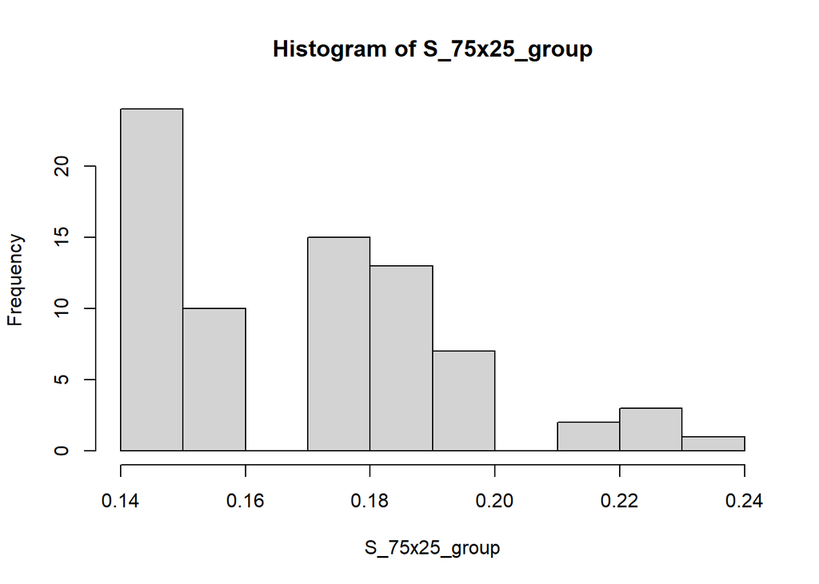

```r
S_75x25_group <- unlist(lapply(df_list2, function(df) mean(df$S[,Nt]==2)))
hist(S_75x25_group)
```

```r
summary(S_75x25_group)
```

```
##    Min. 1st Qu.  Median    Mean 3rd Qu.    Max.
##  0.1467  0.1467  0.1733  0.1719  0.1867  0.2400
```

```r
length(seeds2)
```

```
## [1] 75
```

First, we check the distribution of the resulting **sumLik** in log scale.

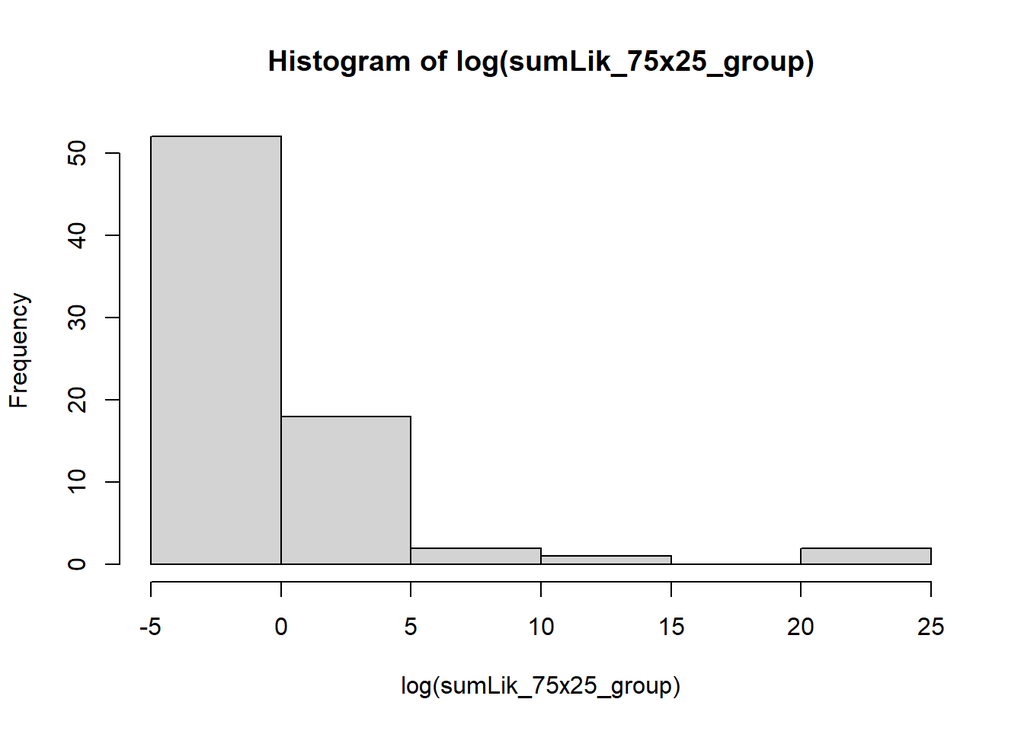

```r
sumLik_75x25_group <- unlist(lapply(filter_list2, function(filter) filter$sumLik_best_NT))
hist(log(sumLik_75x25_group))
```

```r
summary(log(sumLik_75x25_group))
```

```
##    Min. 1st Qu.  Median    Mean 3rd Qu.    Max.
## -4.1833 -3.2670 -2.7305 -0.5692  1.2025 22.8640
```

It seems like there are a few instances which has much higher **sumLik** than others.

Second, we check the distribution of the resulting **delta** in log scale.

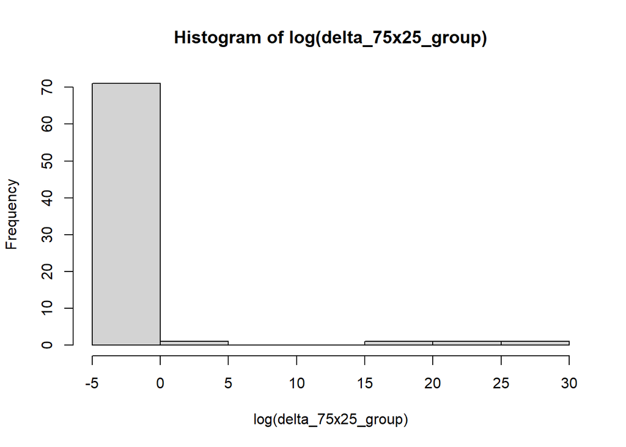

```r
delta_75x25_group <- unlist(lapply(filter_list2, function(filter) filter$delta_N))
hist(log(delta_75x25_group))
```

```r
summary(log(delta_75x25_group))
```

```
##    Min. 1st Qu.  Median    Mean 3rd Qu.    Max.
## -1.8888 -1.5194 -1.3052 -0.2866 -1.0695 28.8967
```

Please note that we prefer a smaller value as it is calculated based on the prediction error.

Next, we turn our attention to how the **sumLik** and **delta** correlate (in log scale). Intuitively, we expect the negative correlation so that higher **sumLik** (maximized likelihood) relates to smaller **delta** (smaller prediction error).

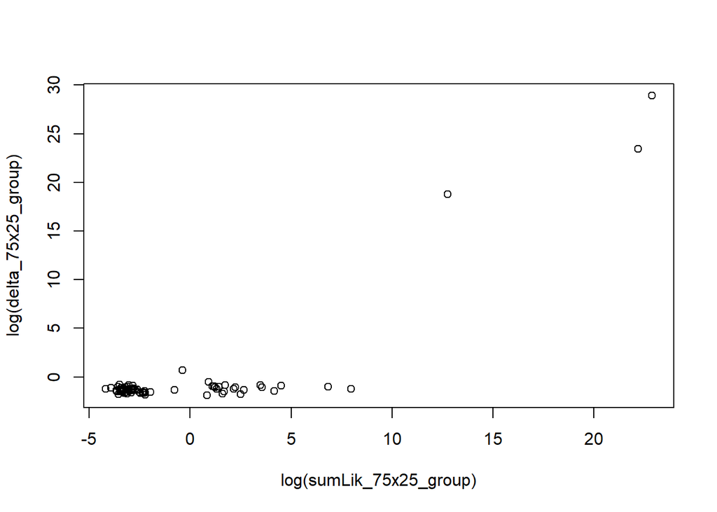

```r
plot(log(sumLik_75x25_group), log(delta_75x25_group))
```

```r
cor(log(sumLik_75x25_group), log(delta_75x25_group))
```

```
## [1] 0.8390143
```

Then, we check the distribution of **sensitivity** and **specificity**. First for **accuracy**

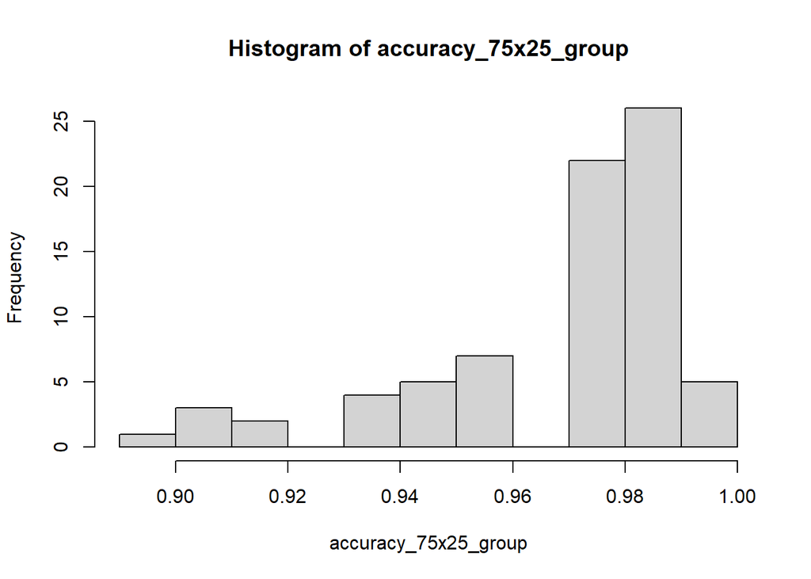

```r
accuracy_75x25_group <- unlist(lapply(filter_list2, function(filter) (filter$output_best$TP + filter$output_best$TN) / N))
hist(accuracy_75x25_group)
```

```r
summary(accuracy_75x25_group)
```

```
##    Min. 1st Qu.  Median    Mean 3rd Qu.    Max.
##  0.8933  0.9600  0.9733  0.9694  0.9867  1.0000
```

Then for **sensitivity**

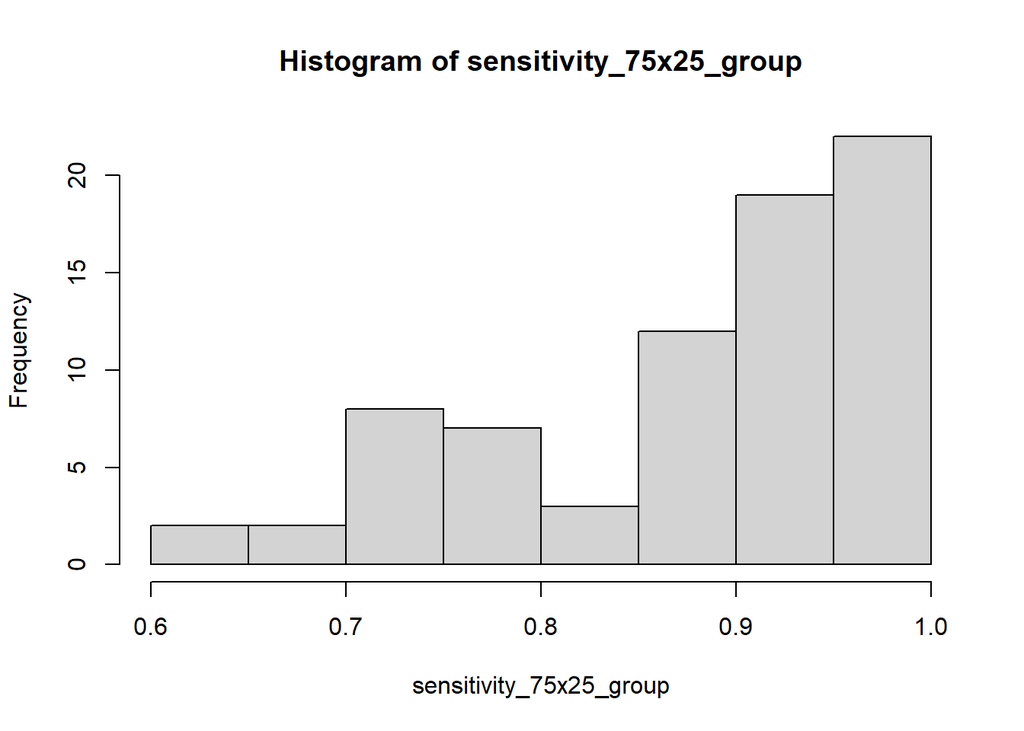

```r
sensitivity_75x25_group <- unlist(lapply(filter_list2, function(filter) filter$output_best$sensitivity))
hist(sensitivity_75x25_group)
```

```r
summary(sensitivity_75x25_group)
```

```
##    Min. 1st Qu.  Median    Mean 3rd Qu.    Max.
##  0.6250  0.8231  0.9167  0.8837  1.0000  1.0000
```

```r
sum(sensitivity_75x25_group<0.8)/length(seeds2)
```

```
## [1] 0.2
```

And for **specificity**

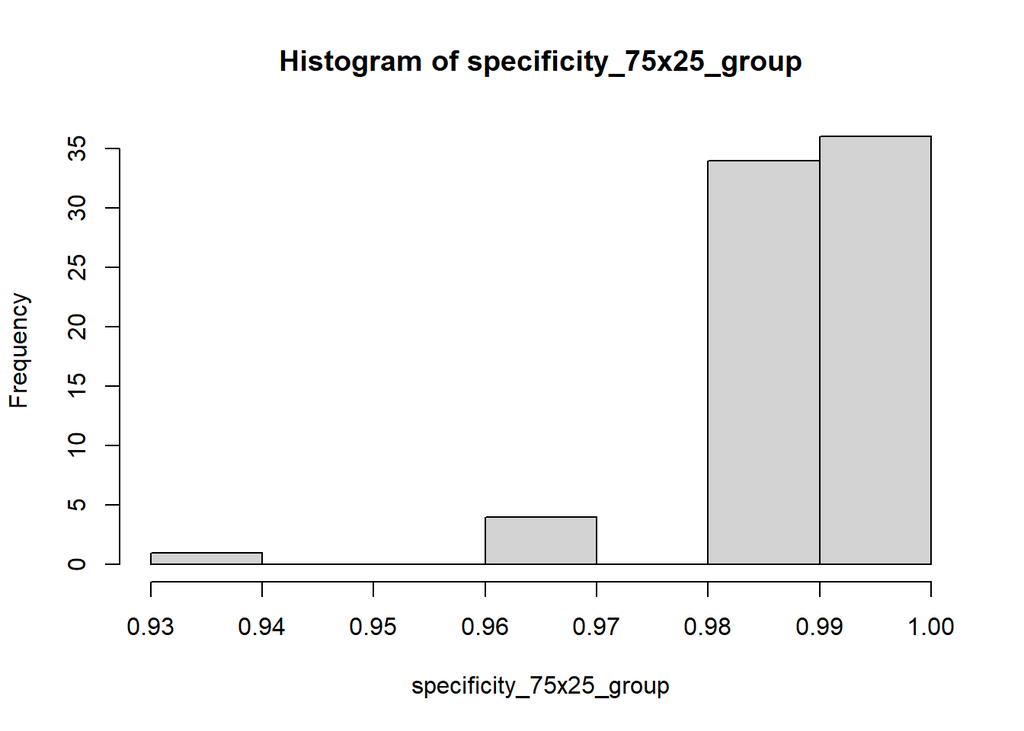

```r
specificity_75x25_group <- unlist(lapply(filter_list2, function(filter) filter$output_best$specificity))
hist(specificity_75x25_group)
```

```r
summary(specificity_75x25_group)
```

```
##    Min. 1st Qu.  Median    Mean 3rd Qu.    Max.
##  0.9375  0.9841  0.9844  0.9902  1.0000  1.0000
```

We can also check the correlation between **sensitivity** and **specificity**.

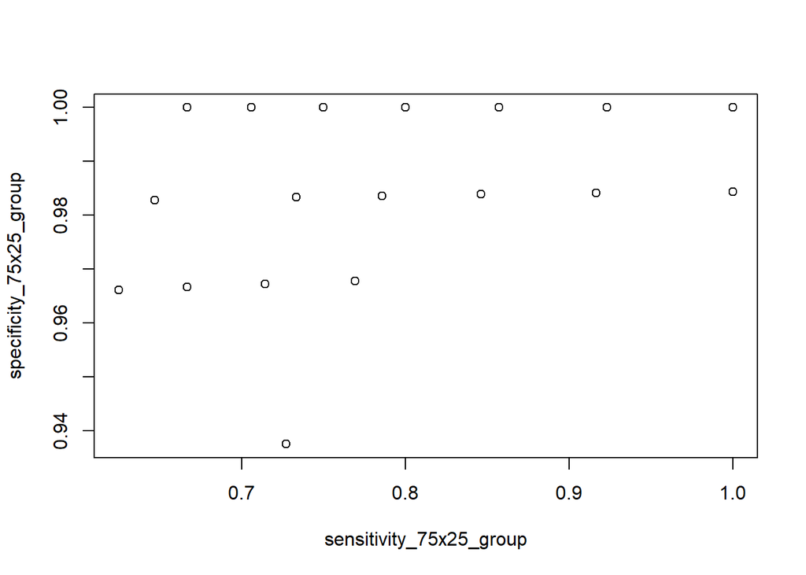

```r
plot(sensitivity_75x25_group, specificity_75x25_group)
```

```r
cor(sensitivity_75x25_group, specificity_75x25_group)
```

```
## [1] 0.1196959
```

Finally we examine our parameter estimation. The distribution of parameter estimation are shown below. True parameter values are in parenthesis.

```r
theta_75x25_group <- do.call(rbind, lapply(filter_list2, function(filter) filter$theta_best))
colnames(theta_75x25_group) <- c('B11_1 (.2)', 'B11_2 (.3)', 'B12_1 (-.1)', 'B12_2 (-.2)', 'B21d_1 (.8)', 'B21d_2 (.8)', 'B22d_1 (.4)', 'B22d_2 (.4)', 'B31_1 (.1)', 'B31_2 (.1)', 'B32_1 (-.1)', 'B32_2 (-.1)', 'Lmdd_1 (1)', 'Lmdd_2 (0)', 'Lmdd_3 (.4)', 'Lmdd_4 (0)', 'Lmdd_5 (.8)', 'Lmdd_6 (0)', 'Lmdd_7 (0)', 'Lmdd_8 (1)', 'Lmdd_9 (0)', 'Lmdd_10 (.5)', 'Lmdd_11 (0)', 'Lmdd_12 (1.2)', 'Qd_1 (.2)', 'Qd_2 (.2)', 'Rd_1 (.3)', 'Rd_2 (.3)', 'Rd_3 (.3)', 'Rd_4 (.3)', 'Rd_5 (.3)', 'Rd_6 (.3)', 'gamma1 (3.5)', 'gamma2_1 (1)', 'gamma2_2 (1)')
summary(theta_75x25_group)
```

```
##    B11_1 (.2)          B11_2 (.3)         B12_1 (-.1)        B12_2 (-.2)
##  Min.   :-0.005404   Min.   :-0.001439   Min.   :-0.53371   Min.   :-0.53115
##  1st Qu.: 0.081249   1st Qu.: 0.111375   1st Qu.:-0.22518   1st Qu.:-0.25584
##  Median : 0.129955   Median : 0.176406   Median :-0.13869   Median :-0.17840
##  Mean   : 0.152380   Mean   : 0.204756   Mean   :-0.16693   Mean   :-0.18115
##  3rd Qu.: 0.178977   3rd Qu.: 0.277566   3rd Qu.:-0.09048   3rd Qu.:-0.08317
##  Max.   : 0.496356   Max.   : 0.628895   Max.   : 0.06342   Max.   : 0.05582
##   B21d_1 (.8)      B21d_2 (.8)      B22d_1 (.4)        B22d_2 (.4)
##  Min.   :0.4511   Min.   :0.5352   Min.   :-0.01166   Min.   :-0.01113
##  1st Qu.:0.7612   1st Qu.:0.7679   1st Qu.: 0.15302   1st Qu.: 0.13462
##  Median :0.8243   Median :0.8668   Median : 0.22621   Median : 0.23602
##  Mean   :0.8181   Mean   :0.8388   Mean   : 0.23627   Mean   : 0.22365
##  3rd Qu.:0.8883   3rd Qu.:0.9109   3rd Qu.: 0.33108   3rd Qu.: 0.29995
##  Max.   :1.0103   Max.   :1.0612   Max.   : 0.48309   Max.   : 0.47765
##    B31_1 (.1)          B31_2 (.1)        B32_1 (-.1)        B32_2 (-.1)
##  Min.   :-0.347024   Min.   :-0.33124   Min.   :-0.62467   Min.   :-0.57264
##  1st Qu.:-0.007436   1st Qu.: 0.00218   1st Qu.:-0.12406   1st Qu.:-0.13436
##  Median : 0.050005   Median : 0.06176   Median :-0.06386   Median :-0.07592
##  Mean   : 0.086535   Mean   : 0.06069   Mean   :-0.06899   Mean   :-0.09483
##  3rd Qu.: 0.153132   3rd Qu.: 0.12392   3rd Qu.:-0.01433   3rd Qu.:-0.03222
##  Max.   : 0.756058   Max.   : 0.38749   Max.   : 0.37832   Max.   : 0.18874
##    Lmdd_1 (1)   Lmdd_2 (0)  Lmdd_3 (.4)       Lmdd_4 (0)  Lmdd_5 (.8)
##  Min.   :1    Min.   :0    Min.   :0.3374   Min.   :0    Min.   :0.5086
##  1st Qu.:1    1st Qu.:0    1st Qu.:0.6161   1st Qu.:0    1st Qu.:0.7685
##  Median :1    Median :0    Median :0.8874   Median :0    Median :0.9561
##  Mean   :1    Mean   :0    Mean   :0.8695   Mean   :0    Mean   :0.9502
##  3rd Qu.:1    3rd Qu.:0    3rd Qu.:1.0833   3rd Qu.:0    3rd Qu.:1.1513
##  Max.   :1    Max.   :0    Max.   :1.3765   Max.   :0    Max.   :1.3701
##    Lmdd_6 (0)   Lmdd_7 (0)   Lmdd_8 (1)   Lmdd_9 (0)  Lmdd_10 (.5)
##  Min.   :0    Min.   :0    Min.   :1    Min.   :0    Min.   :0.3559
##  1st Qu.:0    1st Qu.:0    1st Qu.:1    1st Qu.:0    1st Qu.:0.5964
##  Median :0    Median :0    Median :1    Median :0    Median :0.8009
##  Mean   :0    Mean   :0    Mean   :1    Mean   :0    Mean   :0.8579
##  3rd Qu.:0    3rd Qu.:0    3rd Qu.:1    3rd Qu.:0    3rd Qu.:1.1773
##  Max.   :0    Max.   :0    Max.   :1    Max.   :0    Max.   :1.3402
##   Lmdd_11 (0) Lmdd_12 (1.2)      Qd_1 (.2)          Qd_2 (.2)
##  Min.   :0    Min.   :0.6283   Min.   :0.001000   Min.   :0.001000
##  1st Qu.:0    1st Qu.:0.9183   1st Qu.:0.004685   1st Qu.:0.004092
##  Median :0    Median :1.1226   Median :0.172533   Median :0.172400
##  Mean   :0    Mean   :1.1000   Mean   :0.114878   Mean   :0.114631
```

[output cut: 8 more lines]

```
##  Max.   :0.37870   Max.   :0.37686   Max.   :0.37806   Max.   :0.37895
##    Rd_5 (.3)         Rd_6 (.3)        gamma1 (3.5)    gamma2_1 (1)
##  Min.   :0.01943   Min.   :0.05158   Min.   :4.097   Min.   :-0.08532
##  1st Qu.:0.10601   1st Qu.:0.13486   1st Qu.:4.122   1st Qu.: 0.52889
##  Median :0.37305   Median :0.37229   Median :4.124   Median : 0.88986
##  Mean   :0.27256   Mean   :0.28216   Mean   :4.222   Mean   : 0.90578
##  3rd Qu.:0.37489   3rd Qu.:0.37463   3rd Qu.:4.341   3rd Qu.: 1.24353
##  Max.   :0.37777   Max.   :0.37775   Max.   :4.618   Max.   : 2.12982
##   gamma2_2 (1)
##  Min.   :0.1315
##  1st Qu.:0.4904
##  Median :0.8262
##  Mean   :0.9665
##  3rd Qu.:1.2945
##  Max.   :2.8608
```

Finally, we check the rate of regime-switch prediction by the time of the final prediction which we call the dropout prediction rate.

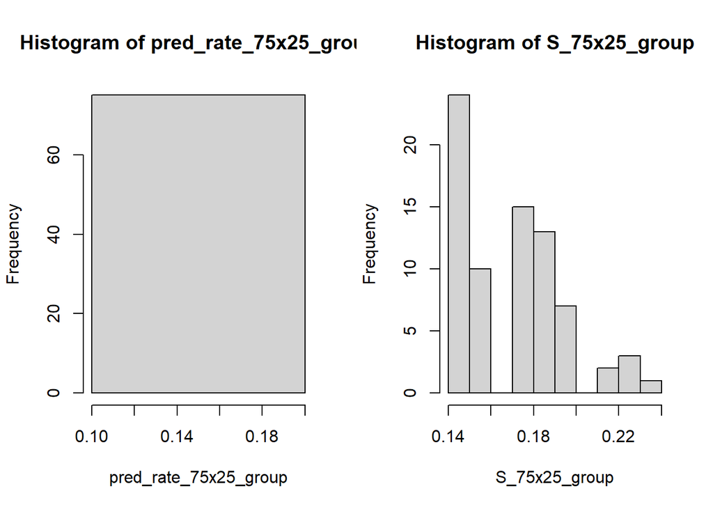

```r
par(mfrow = c(1, 2))
pred_rate_75x25_group <- unlist(lapply(filter_list2, function(filter) (filter$output_best$TP + filter$output_best$FP) / N))
hist(pred_rate_75x25_group)
hist(S_75x25_group)
```

```r
summary(pred_rate_75x25_group)
```

```
##    Min. 1st Qu.  Median    Mean 3rd Qu.    Max.
##    0.16    0.16    0.16    0.16    0.16    0.16
```

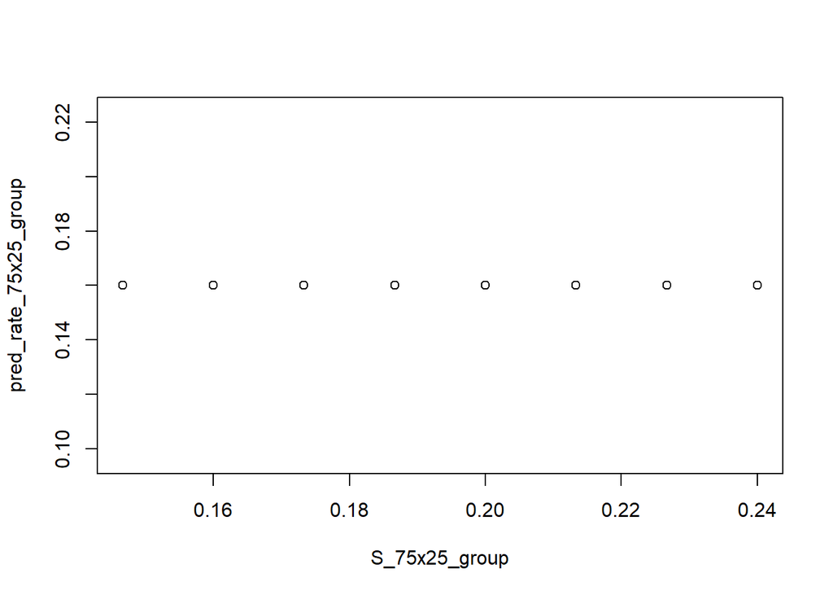

```r
plot(S_75x25_group, pred_rate_75x25_group)
```

```r
cor(S_75x25_group, pred_rate_75x25_group)
```

```
## [1] NA
```

```r
worst_75 <- which.min(sensitivity_75x25_group)
S_75x25_group[worst_75]
```

```
## df_75x25_200
##          0.2
```

```r
summary(S_75x25_group)
```

```
##    Min. 1st Qu.  Median    Mean 3rd Qu.    Max.
##  0.1467  0.1467  0.1733  0.1719  0.1867  0.2400
```

```r
theta_75x25_group[worst_75,]
```

```
##    B11_1 (.2)    B11_2 (.3)   B12_1 (-.1)   B12_2 (-.2)   B21d_1 (.8)
##   0.034606852   0.055867668  -0.296641946  -0.252512813   0.931588054
##   B21d_2 (.8)   B22d_1 (.4)   B22d_2 (.4)    B31_1 (.1)    B31_2 (.1)
##   0.983397424   0.172372624   0.141203701   0.145063490   0.033500709
##   B32_1 (-.1)   B32_2 (-.1)    Lmdd_1 (1)    Lmdd_2 (0)   Lmdd_3 (.4)
##  -0.229347244  -0.136496231   1.000000000   0.000000000   1.026284575
##    Lmdd_4 (0)   Lmdd_5 (.8)    Lmdd_6 (0)    Lmdd_7 (0)    Lmdd_8 (1)
##   0.000000000   1.060566306   0.000000000   0.000000000   1.000000000
##    Lmdd_9 (0)  Lmdd_10 (.5)   Lmdd_11 (0) Lmdd_12 (1.2)     Qd_1 (.2)
##   0.000000000   0.648799598   0.000000000   1.098458767   0.003806647
##     Qd_2 (.2)     Rd_1 (.3)     Rd_2 (.3)     Rd_3 (.3)     Rd_4 (.3)
##   0.002249188   0.263854116   0.074117951   0.299908757   0.081092194
##     Rd_5 (.3)     Rd_6 (.3)  gamma1 (3.5)  gamma2_1 (1)  gamma2_2 (1)
##   0.063026384   0.114618897   4.465000629   1.120351076   1.621150613
```

```r
colMeans(theta_75x25_group)
```

```
##    B11_1 (.2)    B11_2 (.3)   B12_1 (-.1)   B12_2 (-.2)   B21d_1 (.8)
##    0.15238033    0.20475545   -0.16693254   -0.18115251    0.81813422
##   B21d_2 (.8)   B22d_1 (.4)   B22d_2 (.4)    B31_1 (.1)    B31_2 (.1)
##    0.83881202    0.23626524    0.22365078    0.08653475    0.06069062
##   B32_1 (-.1)   B32_2 (-.1)    Lmdd_1 (1)    Lmdd_2 (0)   Lmdd_3 (.4)
##   -0.06898613   -0.09482729    1.00000000    0.00000000    0.86947912
##    Lmdd_4 (0)   Lmdd_5 (.8)    Lmdd_6 (0)    Lmdd_7 (0)    Lmdd_8 (1)
##    0.00000000    0.95022126    0.00000000    0.00000000    1.00000000
##    Lmdd_9 (0)  Lmdd_10 (.5)   Lmdd_11 (0) Lmdd_12 (1.2)     Qd_1 (.2)
##    0.00000000    0.85785019    0.00000000    1.09995451    0.11487801
##     Qd_2 (.2)     Rd_1 (.3)     Rd_2 (.3)     Rd_3 (.3)     Rd_4 (.3)
##    0.11463118    0.28308177    0.26956433    0.27912978    0.28354324
##     Rd_5 (.3)     Rd_6 (.3)  gamma1 (3.5)  gamma2_1 (1)  gamma2_2 (1)
##    0.27255646    0.28215650    4.22227486    0.90577780    0.96647328
```

```r
apply(theta_75x25_group, 2, median)
```

```
##    B11_1 (.2)    B11_2 (.3)   B12_1 (-.1)   B12_2 (-.2)   B21d_1 (.8)
##    0.12995529    0.17640619   -0.13869452   -0.17839703    0.82433122
##   B21d_2 (.8)   B22d_1 (.4)   B22d_2 (.4)    B31_1 (.1)    B31_2 (.1)
##    0.86679691    0.22620864    0.23601507    0.05000526    0.06175517
##   B32_1 (-.1)   B32_2 (-.1)    Lmdd_1 (1)    Lmdd_2 (0)   Lmdd_3 (.4)
##   -0.06386185   -0.07591950    1.00000000    0.00000000    0.88739121
##    Lmdd_4 (0)   Lmdd_5 (.8)    Lmdd_6 (0)    Lmdd_7 (0)    Lmdd_8 (1)
##    0.00000000    0.95607448    0.00000000    0.00000000    1.00000000
##    Lmdd_9 (0)  Lmdd_10 (.5)   Lmdd_11 (0) Lmdd_12 (1.2)     Qd_1 (.2)
##    0.00000000    0.80093110    0.00000000    1.12258875    0.17253278
##     Qd_2 (.2)     Rd_1 (.3)     Rd_2 (.3)     Rd_3 (.3)     Rd_4 (.3)
##    0.17240019    0.37410471    0.37318194    0.37249723    0.37363237
##     Rd_5 (.3)     Rd_6 (.3)  gamma1 (3.5)  gamma2_1 (1)  gamma2_2 (1)
##    0.37305450    0.37229222    4.12443066    0.88986373    0.82615089
```

```r
apply(theta_75x25_group, 2, sd)
```

```
##    B11_1 (.2)    B11_2 (.3)   B12_1 (-.1)   B12_2 (-.2)   B21d_1 (.8)
##    0.10961787    0.13445879    0.11633549    0.12518965    0.09843006
##   B21d_2 (.8)   B22d_1 (.4)   B22d_2 (.4)    B31_1 (.1)    B31_2 (.1)
##    0.10436487    0.13301650    0.12893757    0.15175789    0.13541702
##   B32_1 (-.1)   B32_2 (-.1)    Lmdd_1 (1)    Lmdd_2 (0)   Lmdd_3 (.4)
##    0.12673151    0.12615077    0.00000000    0.00000000    0.28929102
##    Lmdd_4 (0)   Lmdd_5 (.8)    Lmdd_6 (0)    Lmdd_7 (0)    Lmdd_8 (1)
##    0.00000000    0.22404903    0.00000000    0.00000000    0.00000000
##    Lmdd_9 (0)  Lmdd_10 (.5)   Lmdd_11 (0) Lmdd_12 (1.2)     Qd_1 (.2)
##    0.00000000    0.30219770    0.00000000    0.23538861    0.08174485
##     Qd_2 (.2)     Rd_1 (.3)     Rd_2 (.3)     Rd_3 (.3)     Rd_4 (.3)
##    0.08165970    0.13117568    0.14632444    0.13648240    0.13050418
##     Rd_5 (.3)     Rd_6 (.3)  gamma1 (3.5)  gamma2_1 (1)  gamma2_2 (1)
##    0.14234727    0.12922462    0.15078244    0.50494208    0.63896802
```